# protr: R package for generating various numerical representation schemes of protein sequences

# 3 Package Overview

The protr package (Xiao *et al.*, 2015) implemented most of the state-of-the-art protein sequence descriptors with R. Generally, each type of the descriptors (features) can be calculated with a function named `extractX()` in the protr package, where `X` stands for the abbrevation of the descriptor name. The descriptors and the function names implemented are listed below:

- Amino acid composition
  - `extractAAC()` - Amino acid composition
  - `extractDC()` - Dipeptide composition
  - `extractTC()` - Tripeptide composition
- Autocorrelation
  - `extractMoreauBroto()` - Normalized Moreau-Broto autocorrelation
  - `extractMoran()` - Moran autocorrelation
  - `extractGeary()` - Geary autocorrelation
- CTD descriptors
  - `extractCTDC()` - Composition
  - `extractCTDT()` - Transition
  - `extractCTDD()` - Distribution
- Conjoint triad descriptors
  - `extractCTriad()` - Conjoint triad descriptors
- Quasi-sequence-order descriptors
  - `extractSOCN()` - Sequence-order-coupling number
  - `extractQSO()` - Quasi-sequence-order descriptors
- Pseudo-amino acid composition
  - `extractPAAC()` - Pseudo-amino acid composition (PseAAC)
  - `extractAPAAC()` - Amphiphilic pseudo-amino acid composition (APseAAC)
- Profile-based descriptors
  - `extractPSSM()`
  - `extractPSSMAcc()`
  - `extractPSSMFeature()`

The descriptors commonly used in Proteochemometric Modeling (PCM) implemented in protr include:

- `extractScales()`, `extractScalesGap()` - Scales-based descriptors derived by Principal Components Analysis
  - `extractProtFP()`, `extractProtFPGap()` - Scales-based descriptors derived by amino acid properties from AAindex (a.k.a. *Protein Fingerprint*)
  - `extractDescScales()` - Scales-based descriptors derived by 20+ classes of 2D and 3D molecular descriptors (Topological, WHIM, VHSE, etc.)
- `extractFAScales()` - Scales-based descriptors derived by Factor Analysis
- `extractMDSScales()` - Scales-based descriptors derived by Multidimensional Scaling
- `extractBLOSUM()` - BLOSUM and PAM matrix-derived descriptors

The protr package integrates the function of parallelized similarity score computation derived by local or global protein sequence alignment between a list of protein sequences, the sequence alignment computation is provided by `Biostrings`, the corresponding functions listed in the `protr` package include:

- `twoSeqSim()` - Similarity calculation derived by sequence alignment between two protein sequences
- `parSeqSim()` - Parallelized pairwise similarity calculation with a list of protein sequences

The protr package also integrates the function of parallelized similarity score computation derived by Gene Ontology (GO) semantic similarity measures between a list of GO terms / Entrez Gene IDs, the GO similarity computation is provided by `GOSemSim`, the corresponding functions listed in the protr package include:

- `twoGOSim()` - Similarity calculation derived by GO-terms semantic similarity measures between two GO terms / Entrez Gene IDs;
- `parGOSim()` - Pairwise similarity calculation with a list of GO terms / Entrez Gene IDs.

To use the `parSeqSim()` function, we suggest the users to install the packages `foreach` and `doParallel` first, in order to make the parallelized pairwise similarity computation available.

In the following sections, we will introduce the descriptors and function usage in this order.

# 4 Commonly Used Descriptors

**Note**: Users need to intelligently evaluate the underlying details of the descriptors provided, instead of using protr with their data blindly, especially for the descriptor types with more flexibility. It would be wise for the users to use some negative and positive control comparisons where relevant to help guide interpretation of the results.

A protein or peptide sequence with $N$ amino acid residues can be generally represented as $\{\,R_1, R_2, \ldots, R_n\,\}$, where $R_i$ represents the residue at the $i$-th position in the sequence. The labels $i$ and $j$ are used to index amino acid position in a sequence, and $r$, $s$, $t$ are used to represent the amino acid type. The computed descriptors are roughly categorized into 4 groups according to their major applications.

A protein sequence can be partitioned equally into segments. The descriptors designed for the complete sequence, can be often applied to each individual segment.

## 4.1 Amino Acid Composition Descriptor

The amino acid composition describes the fraction of each amino acid type within a protein sequence. The fractions of all 20 natural amino acids are calculated as:

$$f(r) = \frac{N_r}{N} \quad r = 1, 2, \ldots, 20.$$
where $N_r$ is the number of the amino acid type $r$ and $N$ is the length of the sequence.

As was described above, we can use the function `extractAAC()` to extract the descriptors (features) from protein sequences:

```r
library("protr")

x = readFASTA(system.file(
  "protseq/P00750.fasta", package = "protr"))[[1]]

extractAAC(x)
```

```
##          A          R          N          D          C          E
## 0.06405694 0.07117438 0.03914591 0.05160142 0.06761566 0.04804270
##          Q          G          H          I          L          K
## 0.04804270 0.08185053 0.03024911 0.03558719 0.07651246 0.03914591
##          M          F          P          S          T          W
## 0.01245552 0.03202847 0.05338078 0.08896797 0.04448399 0.02313167
##          Y          V
## 0.04270463 0.04982206
```

Here, with the function `readFASTA()` we loaded a single protein sequence (P00750, Tissue-type plasminogen activator) from a FASTA format file. Then extracted the AAC descriptors with `extractAAC()`. The result returned is a named vector, whose elements are tagged with the name of each amino acid.

## 4.2 Dipeptide Composition Descriptor

Dipeptide composition gives a 400-dimensional descriptor, defined as:

$$f(r, s) = \frac{N_{rs}}{N - 1} \quad r, s = 1, 2, \ldots, 20.$$

where $N_{rs}$ is the number of dipeptide represented by amino acid type $r$ and type $s$. Similar to `extractAAC()`, here we use `extractDC()` to compute the descriptors:

```r
dc = extractDC(x)
head(dc, n = 30L)
```

```
##          AA          RA          NA          DA          CA          EA
## 0.003565062 0.003565062 0.000000000 0.007130125 0.003565062 0.003565062
##          QA          GA          HA          IA          LA          KA
## 0.007130125 0.007130125 0.001782531 0.003565062 0.001782531 0.001782531
##          MA          FA          PA          SA          TA          WA
## 0.000000000 0.005347594 0.003565062 0.007130125 0.003565062 0.000000000
##          YA          VA          AR          RR          NR          DR
## 0.000000000 0.000000000 0.003565062 0.007130125 0.005347594 0.001782531
##          CR          ER          QR          GR          HR          IR
## 0.005347594 0.005347594 0.000000000 0.007130125 0.001782531 0.003565062
```

Here we only showed the first 30 elements of the result vector and omitted the rest of the result. The element names of the returned vector are self-explanatory as before.

## 4.3 Tripeptide Composition Descriptor

Tripeptide composition gives a 8000-dimensional descriptor, defined as:

$$f(r, s, t) = \frac{N_{rst}}{N - 2} \quad r, s, t = 1, 2, \ldots, 20$$

where $N_{rst}$ is the number of tripeptides represented by amino acid type $r$, $s$, and $t$. With function `extractTC()`, we can easily obtain the length-8000 descriptor, to save some space, here we also omitted the long outputs:

```r
tc = extractTC(x)
head(tc, n = 36L)
```

```
##         AAA         RAA         NAA         DAA         CAA         EAA
## 0.000000000 0.000000000 0.000000000 0.000000000 0.000000000 0.000000000
##         QAA         GAA         HAA         IAA         LAA         KAA
## 0.001785714 0.000000000 0.000000000 0.000000000 0.000000000 0.000000000
##         MAA         FAA         PAA         SAA         TAA         WAA
## 0.000000000 0.000000000 0.000000000 0.001785714 0.000000000 0.000000000
##         YAA         VAA         ARA         RRA         NRA         DRA
## 0.000000000 0.000000000 0.000000000 0.000000000 0.000000000 0.000000000
##         CRA         ERA         QRA         GRA         HRA         IRA
## 0.000000000 0.000000000 0.000000000 0.001785714 0.000000000 0.000000000
##         LRA         KRA         MRA         FRA         PRA         SRA
## 0.000000000 0.000000000 0.000000000 0.000000000 0.000000000 0.000000000
```

## 4.4 Autocorrelation Descriptors

Autocorrelation descriptors are defined based on the distribution of amino acid properties along the sequence. The amino acid properties used here are various types of amino acids index (Retrieved from the [AAindex Database](http://www.genome.jp/dbget/aaindex.html), see Kawashima *et al.* (1999), Kawashima and Kanehisa (2000), and Kawashima *et al.* (2008); see Figure 2 for an illustrated example). Three types of autocorrelation descriptors are defined here and described below.

All the amino acid indices are centralized and standardized before the calculation, i.e.

$$P_r = \frac{P_r - \bar{P}}{\sigma}$$

where $\bar{P}$ is the average of the property of the 20 amino acids:

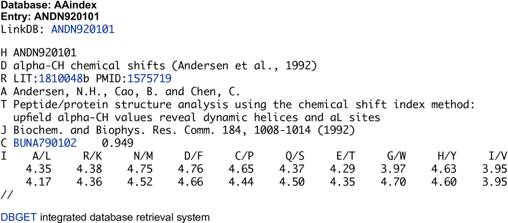

Figure 2: An illustrated example in the AAIndex database

### 4.4.1 Normalized Moreau-Broto autocorrelation descriptors

For protein sequences, the Moreau-Broto autocorrelation descriptors can be defined as:

$$AC(d) = \sum_{i=1}^{N-d} P_i P_{i + d} \quad d = 1, 2, \ldots, \textrm{nlag}$$

where $d$ is called the lag of the autocorrelation; $P_i$ and $P_{i+d}$ are the properties of the amino acids at position $i$ and $i+d$; $\textrm{nlag}$ is the maximum value of the lag.

The normalized Moreau-Broto autocorrelation descriptors are defined as:

$$ATS(d) = \frac{AC(d)}{N-d} \quad d = 1, 2, \ldots, \textrm{nlag}$$

The corresponding function for this descriptor is `extractMoreauBroto()`. A typical call would be:

```r
moreau = extractMoreauBroto(x)
head(moreau, n = 36L)
```

```
##  CIDH920105.lag1  CIDH920105.lag2  CIDH920105.lag3  CIDH920105.lag4
##      0.081573213     -0.016064817     -0.015982990     -0.025739038
##  CIDH920105.lag5  CIDH920105.lag6  CIDH920105.lag7  CIDH920105.lag8
##      0.079058632     -0.042771564     -0.036320847      0.024087298
##  CIDH920105.lag9 CIDH920105.lag10 CIDH920105.lag11 CIDH920105.lag12
##     -0.005273958      0.052274763      0.082170073      0.005419919
## CIDH920105.lag13 CIDH920105.lag14 CIDH920105.lag15 CIDH920105.lag16
##      0.083292042      0.004810584      0.001872446     -0.001531495
## CIDH920105.lag17 CIDH920105.lag18 CIDH920105.lag19 CIDH920105.lag20
##     -0.011917230      0.071161551      0.033473197      0.026882737
## CIDH920105.lag21 CIDH920105.lag22 CIDH920105.lag23 CIDH920105.lag24
##      0.073075402      0.115272790      0.041517897     -0.027025993
## CIDH920105.lag25 CIDH920105.lag26 CIDH920105.lag27 CIDH920105.lag28
##      0.033477388     -0.003245255      0.078117010     -0.028177304
## CIDH920105.lag29 CIDH920105.lag30  BHAR880101.lag1  BHAR880101.lag2
##      0.046695832      0.020584423      0.052740185      0.030804784
##  BHAR880101.lag3  BHAR880101.lag4  BHAR880101.lag5  BHAR880101.lag6
##      0.037170476     -0.058993771      0.070641780     -0.089192490
```

The eight default properties used here are:

- AccNo. CIDH920105 - Normalized Average Hydrophobicity Scales
- AccNo. BHAR880101 - Average Flexibility Indices
- AccNo. CHAM820101 - Polarizability Parameter
- AccNo. CHAM820102 - Free Energy of Solution in Water, kcal/mole
- AccNo. CHOC760101 - Residue Accessible Surface Area in Tripeptide
- AccNo. BIGC670101 - Residue Volume
- AccNo. CHAM810101 - Steric Parameter
- AccNo. DAYM780201 - Relative Mutability

Users can change the property names of AAindex database with the argument `props`. The AAindex data shipped with protr can be loaded by `data(AAindex)`, which has the detailed information of each property. With the argument `customprops` and `nlag`, users can specify their own properties and lag value to calculate with. For example:

```r
# Define 3 custom properties
myprops = data.frame(
  AccNo = c("MyProp1", "MyProp2", "MyProp3"),
  A = c(0.62,  -0.5, 15),  R = c(-2.53,   3, 101),
  N = c(-0.78,  0.2, 58),  D = c(-0.9,    3, 59),
  C = c(0.29,    -1, 47),  E = c(-0.74,   3, 73),
  Q = c(-0.85,  0.2, 72),  G = c(0.48,    0, 1),
  H = c(-0.4,  -0.5, 82),  I = c(1.38, -1.8, 57),
  L = c(1.06,  -1.8, 57),  K = c(-1.5,    3, 73),
  M = c(0.64,  -1.3, 75),  F = c(1.19, -2.5, 91),
  P = c(0.12,     0, 42),  S = c(-0.18, 0.3, 31),
  T = c(-0.05, -0.4, 45),  W = c(0.81, -3.4, 130),
  Y = c(0.26,  -2.3, 107), V = c(1.08, -1.5, 43)
)

# Use 4 properties in the AAindex database, and 3 cutomized properties
moreau2 = extractMoreauBroto(
  x, customprops = myprops,
  props = c(
    "CIDH920105", "BHAR880101",
    "CHAM820101", "CHAM820102",
    "MyProp1", "MyProp2", "MyProp3"))

head(moreau2, n = 36L)
```

```
##  CIDH920105.lag1  CIDH920105.lag2  CIDH920105.lag3  CIDH920105.lag4
##      0.081573213     -0.016064817     -0.015982990     -0.025739038
##  CIDH920105.lag5  CIDH920105.lag6  CIDH920105.lag7  CIDH920105.lag8
##      0.079058632     -0.042771564     -0.036320847      0.024087298
##  CIDH920105.lag9 CIDH920105.lag10 CIDH920105.lag11 CIDH920105.lag12
##     -0.005273958      0.052274763      0.082170073      0.005419919
## CIDH920105.lag13 CIDH920105.lag14 CIDH920105.lag15 CIDH920105.lag16
##      0.083292042      0.004810584      0.001872446     -0.001531495
## CIDH920105.lag17 CIDH920105.lag18 CIDH920105.lag19 CIDH920105.lag20
##     -0.011917230      0.071161551      0.033473197      0.026882737
## CIDH920105.lag21 CIDH920105.lag22 CIDH920105.lag23 CIDH920105.lag24
##      0.073075402      0.115272790      0.041517897     -0.027025993
## CIDH920105.lag25 CIDH920105.lag26 CIDH920105.lag27 CIDH920105.lag28
##      0.033477388     -0.003245255      0.078117010     -0.028177304
## CIDH920105.lag29 CIDH920105.lag30  BHAR880101.lag1  BHAR880101.lag2
##      0.046695832      0.020584423      0.052740185      0.030804784
##  BHAR880101.lag3  BHAR880101.lag4  BHAR880101.lag5  BHAR880101.lag6
##      0.037170476     -0.058993771      0.070641780     -0.089192490
```

About the standard input format of `props` and `customprops`, see `?extractMoreauBroto` for details.

### 4.4.2 Moran autocorrelation descriptors

For protein sequences, the Moran autocorrelation descriptors can be defined as:

$$I(d) = \frac{\frac{1}{N-d} \sum_{i=1}^{N-d} (P_i - \bar{P}') (P_{i+d} - \bar{P}')}{\frac{1}{N} \sum_{i=1}^{N} (P_i - \bar{P}')^2} \quad d = 1, 2, \ldots, 30$$

where $d$, $P_i$, and $P_{i+d}$ are defined in the same way as in the first place; $\bar{P}'$ is the considered property $P$ along the sequence, i.e.,

$$\bar{P}' = \frac{\sum_{i=1}^N P_i}{N}$$

$d$, $P$, $P_i$ and $P_{i+d}$, $\textrm{nlag}$ have the same meaning as above.

With `extractMoran()` (which has the identical parameters as `extractMoreauBroto()`), we can compute the Moran autocorrelation descriptors (only print out the first 36 elements):

```r
# Use the 3 custom properties defined before
# and 4 properties in the AAindex database
moran = extractMoran(
  x, customprops = myprops,
  props = c(
    "CIDH920105", "BHAR880101",
    "CHAM820101", "CHAM820102",
    "MyProp1", "MyProp2", "MyProp3"))

head(moran, n = 36L)
```

```
##  CIDH920105.lag1  CIDH920105.lag2  CIDH920105.lag3  CIDH920105.lag4
##      0.062895724     -0.044827681     -0.045065117     -0.055955678
##  CIDH920105.lag5  CIDH920105.lag6  CIDH920105.lag7  CIDH920105.lag8
##      0.060586377     -0.074128412     -0.067308852     -0.001293384
##  CIDH920105.lag9 CIDH920105.lag10 CIDH920105.lag11 CIDH920105.lag12
##     -0.033747588      0.029392193      0.061789800     -0.023368437
## CIDH920105.lag13 CIDH920105.lag14 CIDH920105.lag15 CIDH920105.lag16
##      0.062769417     -0.024912264     -0.028298043     -0.031584063
## CIDH920105.lag17 CIDH920105.lag18 CIDH920105.lag19 CIDH920105.lag20
##     -0.043466730      0.047830694      0.005883901     -0.001769769
## CIDH920105.lag21 CIDH920105.lag22 CIDH920105.lag23 CIDH920105.lag24
##      0.049334048      0.096427969      0.015147594     -0.060092509
## CIDH920105.lag25 CIDH920105.lag26 CIDH920105.lag27 CIDH920105.lag28
##      0.007549152     -0.033987885      0.056307675     -0.061844453
## CIDH920105.lag29 CIDH920105.lag30  BHAR880101.lag1  BHAR880101.lag2
##      0.021484780     -0.008461776      0.014229951     -0.009142419
##  BHAR880101.lag3  BHAR880101.lag4  BHAR880101.lag5  BHAR880101.lag6
##     -0.003272262     -0.109613332      0.033346233     -0.141538598
```

### 4.4.3 Geary autocorrelation descriptors

Geary autocorrelation descriptors for protein sequences can be defined as:

$$C(d) = \frac{\frac{1}{2(N-d)} \sum_{i=1}^{N-d} (P_i - P_{i+d})^2}{\frac{1}{N-1} \sum_{i=1}^{N} (P_i - \bar{P}')^2} \quad d = 1, 2, \ldots, 30$$

where $d$, $P$, $P_i$, $P_{i+d}$, and $\textrm{nlag}$ have the same meaning as above.

For each amino acid index, there will be $3 \times \textrm{nlag}$ autocorrelation descriptors. The usage of `extractGeary()` is exactly the same as `extractMoreauBroto()` and `extractMoran()`:

```r
# Use the 3 custom properties defined before
# and 4 properties in the AAindex database
geary = extractGeary(
  x, customprops = myprops,
  props = c(
    "CIDH920105", "BHAR880101",
    "CHAM820101", "CHAM820102",
    "MyProp1", "MyProp2", "MyProp3"))

head(geary, n = 36L)
```

```
##  CIDH920105.lag1  CIDH920105.lag2  CIDH920105.lag3  CIDH920105.lag4
##        0.9361830        1.0442920        1.0452843        1.0563467
##  CIDH920105.lag5  CIDH920105.lag6  CIDH920105.lag7  CIDH920105.lag8
##        0.9406031        1.0765517        1.0675786        0.9991363
##  CIDH920105.lag9 CIDH920105.lag10 CIDH920105.lag11 CIDH920105.lag12
##        1.0316555        0.9684585        0.9353130        1.0201990
## CIDH920105.lag13 CIDH920105.lag14 CIDH920105.lag15 CIDH920105.lag16
##        0.9340933        1.0207373        1.0251486        1.0290464
## CIDH920105.lag17 CIDH920105.lag18 CIDH920105.lag19 CIDH920105.lag20
##        1.0414375        0.9494403        0.9905987        0.9987183
## CIDH920105.lag21 CIDH920105.lag22 CIDH920105.lag23 CIDH920105.lag24
##        0.9472542        0.9010009        0.9828848        1.0574098
## CIDH920105.lag25 CIDH920105.lag26 CIDH920105.lag27 CIDH920105.lag28
##        0.9897955        1.0290018        0.9400066        1.0584150
## CIDH920105.lag29 CIDH920105.lag30  BHAR880101.lag1  BHAR880101.lag2
##        0.9762904        1.0029734        0.9818711        1.0051730
##  BHAR880101.lag3  BHAR880101.lag4  BHAR880101.lag5  BHAR880101.lag6
##        0.9967069        1.1012905        0.9595859        1.1337056
```

## 4.5 Composition/Transition/Distribution

The CTD descriptors are developed by Dubchak *et al.* (1995) and Dubchak *et al.* (1999).

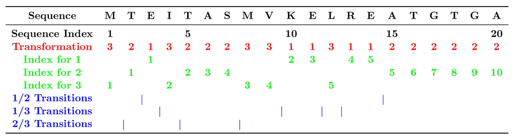

Figure 3: The sequence of a hypothetic protein indicating the construction of composition, transition, and distribution descriptors of a protein. Sequence index indicates the position of an amino acid in the sequence. The index for each type of amino acids in the sequence (`1`, `2` or `3`) indicates the position of the first, second, third, … of that type of amino acid. 1/2 transition indicates the position of `12` or `21` pairs in the sequence (1/3 and 2/3 are defined in the same way).

**Step 1: Sequence Encoding**

The amino acids are categorized into three classes according to its attribute, and each amino acid is encoded by one of the indices 1, 2, 3 according to which class it belongs. The attributes used here include hydrophobicity, normalized van der Waals volume, polarity, and polarizability. The corresponding classification for each attribute is listed in Table 1.

Table 1: Amino acid attributes, and the three-group classification of the 20 amino acids by each attribute

[output not shown]

For example, for a given sequence `MTEITAAMVKELRESTGAGA`, it will be encoded as `32132223311311222222` according to its hydrophobicity.

**Step 2: Compute Composition, Transition, and Distribution Descriptors**

Three types of descriptors, *Composition* (*C*), *Transition* (*T*), and *Distribution* (*D*) can be calculated for a given attribute as follows.

### 4.5.1 Composition

$$C_r = \frac{n_r}{n} \quad r = 1, 2, 3$$

where $n_r$ is the number of amino acid type $r$ in the encoded sequence; $N$ is the length of the sequence. An example for `extractCTDC()`:

```r
extractCTDC(x)
```

```
##  hydrophobicity.Group1  hydrophobicity.Group2  hydrophobicity.Group3
##             0.29715302             0.40569395             0.29715302
## normwaalsvolume.Group1 normwaalsvolume.Group2 normwaalsvolume.Group3
##             0.45195730             0.29715302             0.25088968
##        polarity.Group1        polarity.Group2        polarity.Group3
##             0.33985765             0.33274021             0.32740214
##  polarizability.Group1  polarizability.Group2  polarizability.Group3
##             0.33096085             0.41814947             0.25088968
##          charge.Group1          charge.Group2          charge.Group3
##             0.11032028             0.79003559             0.09964413
## secondarystruct.Group1 secondarystruct.Group2 secondarystruct.Group3
##             0.38967972             0.29537367             0.31494662
##   solventaccess.Group1   solventaccess.Group2   solventaccess.Group3
##             0.43060498             0.29715302             0.27224199
```

The result shows the elements who are named as `PropertyNumber.GroupNumber` in the returned vector.

### 4.5.2 Transition

A transition from class 1 to 2 is the percent frequency with which 1 is followed by 2 or 2 is followed by 1 in the encoded sequences. The transition descriptor can be computed as

$$T_{rs} = \frac{n_{rs} + n_{sr}}{N - 1} \quad rs = \text{12}, \text{13}, \text{23}$$

where $n_{rs}$, $n_{sr}$ are the numbers of dipeptide encoded as `rs` and `sr` in the sequence; $N$ is the length of the sequence. An example for `extractCTDT()`:

```r
extractCTDT(x)
```

```
## prop1.Tr1221 prop1.Tr1331 prop1.Tr2332 prop2.Tr1221 prop2.Tr1331
##   0.27094474   0.16042781   0.23351159   0.26737968   0.22638146
## prop2.Tr2332 prop3.Tr1221 prop3.Tr1331 prop3.Tr2332 prop4.Tr1221
##   0.17112299   0.21033868   0.20499109   0.23707665   0.27272727
## prop4.Tr1331 prop4.Tr2332 prop5.Tr1221 prop5.Tr1331 prop5.Tr2332
##   0.15151515   0.24598930   0.18181818   0.02139037   0.15686275
## prop6.Tr1221 prop6.Tr1331 prop6.Tr2332 prop7.Tr1221 prop7.Tr1331
##   0.21925134   0.22816399   0.15864528   0.25133690   0.21568627
## prop7.Tr2332
##   0.18003565
```

### 4.5.3 Distribution

The *distribution* descriptor describes the distribution of each attribute in the sequence.

There are five “distribution” descriptors for each attribute and they are the position percents in the whole sequence for the first residue, 25% residues, 50% residues, 75% residues, and 100% residues for a certain encoded class. For example, there are 10 residues encoded as `2` in the above example, the positions for the first residue `2`, the 2nd residue `2` (25% * 10 = 2), the 5th `2` residue (50% * 10 = 5), the 7th `2` (75% * 10 = 7) and the 10th residue `2` (100% * 10) in the encoded sequence are 2, 5, 15, 17, 20, so that the distribution descriptors for `2` are: 10.0 (2/20 * 100), 25.0 (5/20 * 100), 75.0 (15/20 * 100), 85.0 (17/20 * 100), 100.0 (20/20 * 100).

To compute the distribution descriptor, use `extractCTDD()`:

```r
extractCTDD(x)
```

```
##   prop1.G1.residue0  prop1.G1.residue25  prop1.G1.residue50
##           0.3558719          23.1316726          50.1779359
##  prop1.G1.residue75 prop1.G1.residue100   prop1.G2.residue0
##          73.8434164          99.8220641           0.5338078
##  prop1.G2.residue25  prop1.G2.residue50  prop1.G2.residue75
##          27.4021352          47.3309609          75.2669039
## prop1.G2.residue100   prop1.G3.residue0  prop1.G3.residue25
##         100.0000000           0.1779359          19.5729537
##  prop1.G3.residue50  prop1.G3.residue75 prop1.G3.residue100
##          51.7793594          75.6227758          99.6441281
##   prop2.G1.residue0  prop2.G1.residue25  prop2.G1.residue50
##           0.3558719          25.6227758          48.0427046
##  prop2.G1.residue75 prop2.G1.residue100   prop2.G2.residue0
##          75.4448399         100.0000000           1.4234875
##  prop2.G2.residue25  prop2.G2.residue50  prop2.G2.residue75
##          23.3096085          54.4483986          76.3345196
## prop2.G2.residue100   prop2.G3.residue0  prop2.G3.residue25
##          99.4661922           0.1779359          22.7758007
##  prop2.G3.residue50  prop2.G3.residue75 prop2.G3.residue100
##          48.9323843          69.5729537          99.8220641
##   prop3.G1.residue0  prop3.G1.residue25  prop3.G1.residue50
##           0.1779359          20.9964413          50.8896797
##  prop3.G1.residue75 prop3.G1.residue100   prop3.G2.residue0
##          74.5551601          99.6441281           0.5338078
##  prop3.G2.residue25  prop3.G2.residue50  prop3.G2.residue75
##          26.5124555          46.2633452          75.4448399
## prop3.G2.residue100   prop3.G3.residue0  prop3.G3.residue25
##         100.0000000           0.3558719          24.1992883
##  prop3.G3.residue50  prop3.G3.residue75 prop3.G3.residue100
##          50.5338078          73.8434164          99.8220641
##   prop4.G1.residue0  prop4.G1.residue25  prop4.G1.residue50
##           0.3558719          26.5124555          48.3985765
##  prop4.G1.residue75 prop4.G1.residue100   prop4.G2.residue0
##          76.1565836          99.2882562           1.4234875
##  prop4.G2.residue25  prop4.G2.residue50  prop4.G2.residue75
##          21.5302491          51.4234875          75.8007117
## prop4.G2.residue100   prop4.G3.residue0  prop4.G3.residue25
##         100.0000000           0.1779359          22.7758007
##  prop4.G3.residue50  prop4.G3.residue75 prop4.G3.residue100
##          48.9323843          69.5729537          99.8220641
```

[output cut: 15 more lines]

```
##          21.5302491          49.2882562          70.8185053
## prop6.G2.residue100   prop6.G3.residue0  prop6.G3.residue25
##          98.9323843           0.3558719          29.0035587
##  prop6.G3.residue50  prop6.G3.residue75 prop6.G3.residue100
##          48.2206406          77.4021352         100.0000000
##   prop7.G1.residue0  prop7.G1.residue25  prop7.G1.residue50
##           0.5338078          23.4875445          50.0000000
##  prop7.G1.residue75 prop7.G1.residue100   prop7.G2.residue0
##          74.5551601          98.9323843           0.3558719
##  prop7.G2.residue25  prop7.G2.residue50  prop7.G2.residue75
##          23.1316726          50.1779359          73.8434164
## prop7.G2.residue100   prop7.G3.residue0  prop7.G3.residue25
##          99.8220641           0.1779359          27.2241993
##  prop7.G3.residue50  prop7.G3.residue75 prop7.G3.residue100
##          48.0427046          75.4448399         100.0000000
```

## 4.6 Conjoint Triad Descriptors

Conjoint triad descriptors are proposed by Shen *et al.* (2007). The conjoint triad descriptors were used to model protein-protein interactions based on the classification of amino acids. In this approach, each protein sequence is represented by a vector space consisting of descriptors of amino acids. To reduce the dimensions of vector space, the 20 amino acids were clustered into several classes according to their dipoles and volumes of the side chains. The conjoint triad descriptors are calculated as follows:

**Step 1: Classification of Amino Acids**

Electrostatic and hydrophobic interactions dominate protein-protein interactions. These two kinds of interactions may be reflected by the dipoles and volumes of the side chains of amino acids, respectively. Accordingly, these two parameters were calculated by using the density-functional theory method B3LYP/6-31G and molecular modeling approach. Based on the dipoles and volumes of the side chains, the 20 amino acids can be clustered into seven classes (See Table 2). Amino acids within the same class likely involve synonymous mutations because of their similar characteristics.

Table 2: Classification of amino acids based on dipoles and volumes of the side chains

| No. | Dipole Scale$^1$ | Volume Scale$^2$ | Class |
| --- | --- | --- | --- |
| 1 | $-$ | $-$ | Ala, Gly, Val |
| 2 | $-$ | $+$ | Ile, Leu, Phe, Pro |
| 3 | $+$ | $+$ | Tyr, Met, Thr, Ser |
| 4 | $++$ | $+$ | His, Asn, Gln, Tpr |
| 5 | $+++$ | $+$ | Arg, Lys |
| 6 | $+'+'+'$ | $+$ | Asp, Glu |
| 7 | $+^3$ | $+$ | Cys |

<sup>1</sup> Dipole Scale (Debye): $-$, Dipole < 1.0; $+$, 1.0 < Dipole < 2.0; $++$, 2.0 < Dipole < 3.0; $+++$, Dipole > 3.0; $+'+'+'$, Dipole > 3.0 with opposite orientation.

<sup>2</sup> Volume Scale ($\overset{\lower.5em\circ}{\mathrm{A}}\lower.01em^3$): $-$, Volume < 50; $+$, Volume > 50.

<sup>3</sup> Cys is separated from class 3 because of its ability to form disulfide bonds.

**Step 2: Conjoint Triad Calculation**

The conjoint triad descriptors considered the properties of one amino acid and its vicinal amino acids and regarded any three continuous amino acids as a unit. Thus, the triads can be differentiated according to the classes of amino acids, i.e., triads composed by three amino acids belonging to the same classes, such as ART and VKS, can be treated identically. To conveniently represent a protein, we first use a binary space $(\mathbf{V}, \mathbf{F})$ to represent a protein sequence. Here, $\mathbf{V}$ is the vector space of the sequence features, and each feature $v_i$ represents a sort of triad type; $\mathbf{F}$ is the frequency vector corresponding to $\mathbf{V}$, and the value of the $i$-th dimension of $\mathbf{F} (f_i)$ is the frequency of type $v_i$ appearing in the protein sequence. For the amino acids that have been catogorized into seven classes, the size of $\mathbf{V}$ should be $7 \times 7 \times 7$; thus $i = 1, 2, \ldots, 343$. The detailed description for ($\mathbf{V}$, $\mathbf{F}$) is illustrated in Figure 4.

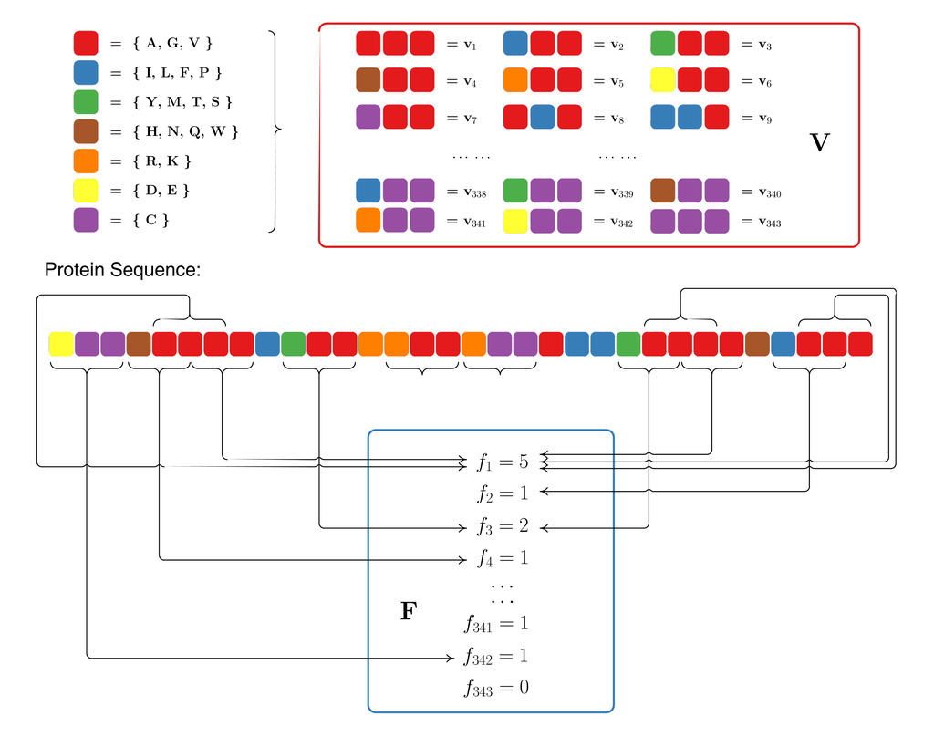

Figure 4: Schematic diagram for constructing the vector space ($\mathbf{V}$, $\mathbf{F}$) of protein sequences. $\mathbf{V}$ is the vector space of the sequence features; each feature ($v_i$) represents a triad composed of three consecutive amino acids; $\mathbf{F}$ is the frequency vector corresponding to $\mathbf{V}$, and the value of the $i$-th dimension of $\mathbf{F} (f_i)$ is the frequency that $v_i$ triad appeared in the protein sequence.

Clearly, each protein correlates to the length (number of amino acids) of protein. In general, a long protein would have a large value of $f_i$, which complicates the comparison between two heterogeneous proteins. Thus, we defined a new parameter, $d_i$, by normalizing $f_i$ with the following equation:

$$d_i = \frac{f_i - \min\{\,f_1, f_2 , \ldots, f_{343}\,\}}{\max\{\,f_1, f_2, \ldots, f_{343}\,\}}$$

The numerical value of $d_i$ of each protein ranges from 0 to 1, which thereby enables the comparison between proteins. Accordingly, we obtain another vector space (designated $\mathbf{D}$) consisting of $d_i$ to represent protein.

To compute conjoint triads of protein sequences, we can simply use:

```r
ctriad = extractCTriad(x)
head(ctriad, n = 65L)
```

```
## VS111 VS211 VS311 VS411 VS511 VS611 VS711 VS121 VS221 VS321 VS421 VS521
##   0.1   0.3   0.6   0.2   0.4   0.0   0.3   1.0   0.6   0.5   0.0   0.2
## VS621 VS721 VS131 VS231 VS331 VS431 VS531 VS631 VS731 VS141 VS241 VS341
##   0.3   0.0   0.2   0.4   0.5   0.2   0.3   0.3   0.1   0.3   0.3   0.2
## VS441 VS541 VS641 VS741 VS151 VS251 VS351 VS451 VS551 VS651 VS751 VS161
##   0.2   0.0   0.1   0.2   0.2   0.2   0.5   0.1   0.2   0.0   0.0   0.1
## VS261 VS361 VS461 VS561 VS661 VS761 VS171 VS271 VS371 VS471 VS571 VS671
##   0.4   0.2   0.3   0.2   0.0   0.1   0.1   0.3   0.1   0.0   0.1   0.0
## VS771 VS112 VS212 VS312 VS412 VS512 VS612 VS712 VS122 VS222 VS322 VS422
##   0.1   0.8   0.4   0.4   0.6   0.1   0.5   0.2   0.8   0.5   0.2   0.3
## VS522 VS622 VS722 VS132 VS232
##   0.2   0.0   0.2   0.1   0.3
```

by which we only outputted the first 65 of total 343 dimension to save space.

## 4.7 Quasi-sequence-order Descriptors

The quasi-sequence-order descriptors are proposed by Chou (2000). They are derived from the distance matrix between the 20 amino acids.

### 4.7.1 Sequence-order-coupling number

The $d$-th rank sequence-order-coupling number is defined as:

$$\tau_d = \sum_{i=1}^{N-d} (d_{i, i+d})^2 \quad d = 1, 2, \ldots, \textrm{maxlag}$$

where $d_{i, i+d}$ is the distance between the two amino acids at position $i$ and $i+d$.

**Note**: maxlag is the maximum lag and the length of the protein must be not less than $\textrm{maxlag}$.

The function `extractSOCN()` is used for computing the sequence-order-coupling numbers:

```r
extractSOCN(x)
```

```
##  Schneider.lag1  Schneider.lag2  Schneider.lag3  Schneider.lag4
##        204.2036        199.8708        206.8102        197.4828
##  Schneider.lag5  Schneider.lag6  Schneider.lag7  Schneider.lag8
##        193.3366        208.1936        195.5476        200.9789
##  Schneider.lag9 Schneider.lag10 Schneider.lag11 Schneider.lag12
##        196.7110        193.9931        199.7031        204.9389
## Schneider.lag13 Schneider.lag14 Schneider.lag15 Schneider.lag16
##        187.0140        198.4702        205.4526        193.1274
## Schneider.lag17 Schneider.lag18 Schneider.lag19 Schneider.lag20
##        187.3529        190.4949        202.8853        198.5299
## Schneider.lag21 Schneider.lag22 Schneider.lag23 Schneider.lag24
##        191.1013        185.0074        189.9857        202.7113
## Schneider.lag25 Schneider.lag26 Schneider.lag27 Schneider.lag28
##        201.6267        194.5770        185.9939        204.1297
## Schneider.lag29 Schneider.lag30   Grantham.lag1   Grantham.lag2
##        191.1629        183.9073    6674686.0000    6761609.0000
##   Grantham.lag3   Grantham.lag4   Grantham.lag5   Grantham.lag6
##    7138892.0000    6748261.0000    6291229.0000    6839853.0000
##   Grantham.lag7   Grantham.lag8   Grantham.lag9  Grantham.lag10
##    6594164.0000    6556148.0000    6620183.0000    6770614.0000
##  Grantham.lag11  Grantham.lag12  Grantham.lag13  Grantham.lag14
##    6495689.0000    6865537.0000    6297267.0000    6498247.0000
##  Grantham.lag15  Grantham.lag16  Grantham.lag17  Grantham.lag18
##    6615566.0000    6572680.0000    6569081.0000    6173947.0000
##  Grantham.lag19  Grantham.lag20  Grantham.lag21  Grantham.lag22
##    6570829.0000    6471308.0000    6461649.0000    5939432.0000
##  Grantham.lag23  Grantham.lag24  Grantham.lag25  Grantham.lag26
##    6532121.0000    6652472.0000    6480660.0000    6382281.0000
##  Grantham.lag27  Grantham.lag28  Grantham.lag29  Grantham.lag30
##    6276521.0000    6537634.0000    6442991.0000    6350157.0000
```

Users can also specify the maximum lag value with the `nlag` argument.

**Note**: In addition to Schneider-Wrede physicochemical distance matrix (Schneider and Wrede, 1994) used by Kuo-Chen Chou, another chemical distance matrix by Grantham (1974) is also used here. So the descriptors dimension will be `nlag * 2`. The quasi-sequence-order descriptors described next also utilized the two matrices.

### 4.7.2 Quasi-sequence-order descriptors

For each amino acid type, a quasi-sequence-order descriptor can be defined as:

$$X_r = \frac{f_r}{\sum_{r=1}^{20} f_r + w \sum_{d=1}^{\textrm{maxlag}} \tau_d} \quad r = 1, 2, \ldots, 20$$

where $f_r$ is the normalized occurrence for amino acid type $i$ and $w$ is a weighting factor ($w=0.1$). These are the first 20 quasi-sequence-order descriptors. The other 30 quasi-sequence-order are defined as:

$$X_d = \frac{w \tau_{d-20}}{\sum_{r=1}^{20} f_r + w \sum_{d=1}^{\textrm{maxlag}} \tau_d} \quad d = 21, 22, \ldots, 20 + \textrm{maxlag}$$

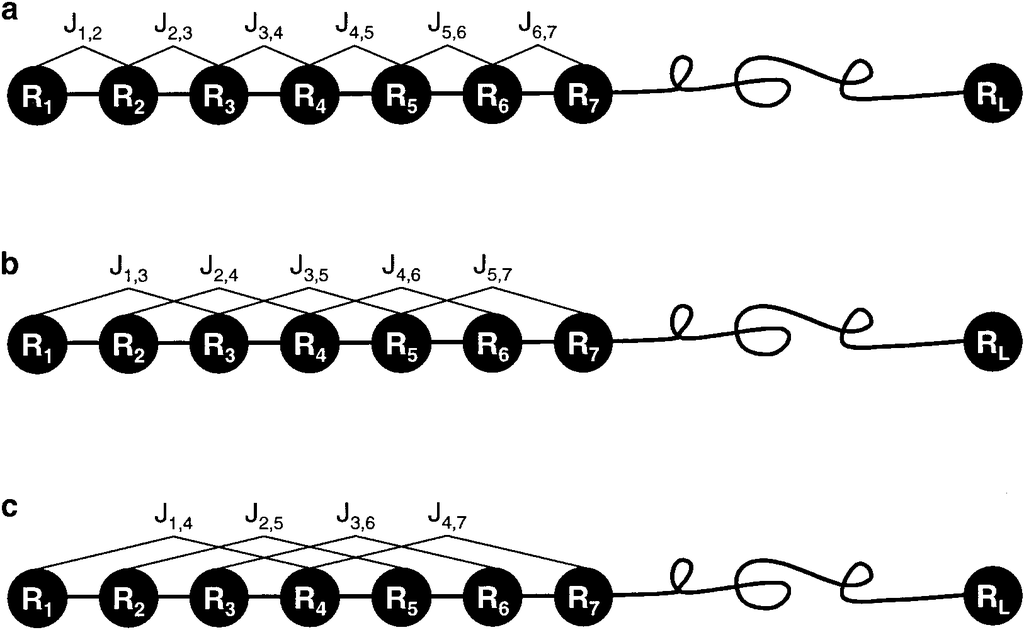

Figure 5: A schematic drawing to show (a) the 1st-rank, (b) the 2nd-rank, and (3) the 3rd-rank sequence-order-coupling mode along a protein sequence. (a) Reflects the coupling mode between all the most contiguous residues, (b) that between all the 2nd most contiguous residues, and (c) that between all the 3rd most contiguous residues. This figure is from Chou (2000).

A minimal example for `extractQSO()`:

```r
extractQSO(x)
```

```
##  Schneider.Xr.A  Schneider.Xr.R  Schneider.Xr.N  Schneider.Xr.D
##    6.096218e-02    6.773576e-02    3.725467e-02    4.910842e-02
##  Schneider.Xr.C  Schneider.Xr.E  Schneider.Xr.Q  Schneider.Xr.G
##    6.434897e-02    4.572164e-02    4.572164e-02    7.789612e-02
##  Schneider.Xr.H  Schneider.Xr.I  Schneider.Xr.L  Schneider.Xr.K
##    2.878770e-02    3.386788e-02    7.281594e-02    3.725467e-02
##  Schneider.Xr.M  Schneider.Xr.F  Schneider.Xr.P  Schneider.Xr.S
##    1.185376e-02    3.048109e-02    5.080182e-02    8.466970e-02
##  Schneider.Xr.T  Schneider.Xr.W  Schneider.Xr.Y  Schneider.Xr.V
##    4.233485e-02    2.201412e-02    4.064145e-02    4.741503e-02
##   Grantham.Xr.A   Grantham.Xr.R   Grantham.Xr.N   Grantham.Xr.D
##    1.835033e-06    2.038926e-06    1.121409e-06    1.478221e-06
##   Grantham.Xr.C   Grantham.Xr.E   Grantham.Xr.Q   Grantham.Xr.G
##    1.936980e-06    1.376275e-06    1.376275e-06    2.344765e-06
##   Grantham.Xr.H   Grantham.Xr.I   Grantham.Xr.L   Grantham.Xr.K
##    8.665435e-07    1.019463e-06    2.191845e-06    1.121409e-06
##   Grantham.Xr.M   Grantham.Xr.F   Grantham.Xr.P   Grantham.Xr.S
##    3.568120e-07    9.175167e-07    1.529194e-06    2.548657e-06
##   Grantham.Xr.T   Grantham.Xr.W   Grantham.Xr.Y   Grantham.Xr.V
##    1.274329e-06    6.626509e-07    1.223356e-06    1.427248e-06
##  Schneider.Xd.1  Schneider.Xd.2  Schneider.Xd.3  Schneider.Xd.4
##    3.457972e-02    3.384600e-02    3.502111e-02    3.344162e-02
##  Schneider.Xd.5  Schneider.Xd.6  Schneider.Xd.7  Schneider.Xd.8
##    3.273951e-02    3.525537e-02    3.311390e-02    3.403364e-02
##  Schneider.Xd.9 Schneider.Xd.10 Schneider.Xd.11 Schneider.Xd.12
##    3.331093e-02    3.285068e-02    3.381760e-02    3.470422e-02
## Schneider.Xd.13 Schneider.Xd.14 Schneider.Xd.15 Schneider.Xd.16
##    3.166883e-02    3.360882e-02    3.479121e-02    3.270408e-02
## Schneider.Xd.17 Schneider.Xd.18 Schneider.Xd.19 Schneider.Xd.20
##    3.172623e-02    3.225829e-02    3.435647e-02    3.361893e-02
## Schneider.Xd.21 Schneider.Xd.22 Schneider.Xd.23 Schneider.Xd.24
##    3.236099e-02    3.132904e-02    3.217206e-02    3.432701e-02
## Schneider.Xd.25 Schneider.Xd.26 Schneider.Xd.27 Schneider.Xd.28
##    3.414334e-02    3.294954e-02    3.149609e-02    3.456720e-02
## Schneider.Xd.29 Schneider.Xd.30   Grantham.Xd.1   Grantham.Xd.2
##    3.237140e-02    3.114275e-02    3.402298e-02    3.446605e-02
##   Grantham.Xd.3   Grantham.Xd.4   Grantham.Xd.5   Grantham.Xd.6
##    3.638918e-02    3.439801e-02    3.206838e-02    3.486488e-02
##   Grantham.Xd.7   Grantham.Xd.8   Grantham.Xd.9  Grantham.Xd.10
##    3.361253e-02    3.341875e-02    3.374516e-02    3.451195e-02
##  Grantham.Xd.11  Grantham.Xd.12  Grantham.Xd.13  Grantham.Xd.14
##    3.311057e-02    3.499580e-02    3.209915e-02    3.312361e-02
##  Grantham.Xd.15  Grantham.Xd.16  Grantham.Xd.17  Grantham.Xd.18
##    3.372162e-02    3.350302e-02    3.348467e-02    3.147055e-02
##  Grantham.Xd.19  Grantham.Xd.20  Grantham.Xd.21  Grantham.Xd.22
##    3.349358e-02    3.298629e-02    3.293706e-02    3.027516e-02
##  Grantham.Xd.23  Grantham.Xd.24  Grantham.Xd.25  Grantham.Xd.26
##    3.329628e-02    3.390974e-02    3.303396e-02    3.253250e-02
##  Grantham.Xd.27  Grantham.Xd.28  Grantham.Xd.29  Grantham.Xd.30
##    3.199340e-02    3.332438e-02    3.284195e-02    3.236875e-02
```

where users can also specify the maximum lag with the argument `nlag` and the weighting factor with the argument `w`.

## 4.8 Pseudo-Amino Acid Composition (PseAAC)

This group of descriptors are proposed by Chou (2001). PseAAC descriptors are also named as the *type 1 pseudo-amino acid composition*. Let $H_1^o (i)$, $H_2^o (i)$, $M^o (i)$ ($i=1, 2, 3, \ldots, 20$) be the original hydrophobicity values, the original hydrophilicity values and the original side chain masses of the 20 natural amino acids, respectively. They are converted to following qualities by a standard conversion:

$$H_1 (i) = \frac{H_1^o (i) - \frac{1}{20} \sum_{i=1}^{20} H_1^o (i)}{\sqrt{\frac{\sum_{i=1}^{20} [H_1^o (i) - \frac{1}{20} \sum_{i=1}^{20} H_1^o (i) ]^2}{20}}}$$

$H_2^o (i)$ and $M^o (i)$ are normalized as $H_2 (i)$ and $M (i)$ in the same way.

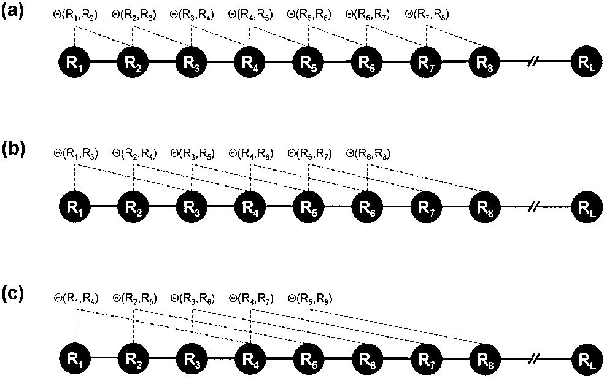

Figure 6: A schematic drawing to show (a) the first-tier, (b) the second-tier, and (3) the third-tiersequence order correlation mode along a protein sequence. Panel (a) reflects the correlation mode between all the most contiguous residues, panel (b) that between all the second-most contiguous residues, and panel (c) that between all the third-most contiguous residues. This figure is from Chou (2001).

Then, a correlation function can be defines as

$$\Theta (R_i, R_j) = \frac{1}{3} \bigg\{ [ H_1 (R_i) - H_1 (R_j) ]^2 + [ H_2 (R_i) - H_2 (R_j) ]^2 + [ M (R_i) - M (R_j) ]^2 \bigg\}$$

This correlation function is actually an average value for the three amino acid properties: hydrophobicity value, hydrophilicity value and side chain mass. Therefore, we can extend this definition of correlation functions for one amino acid property or for a set of $n$ amino acid properties.

For one amino acid property, the correlation can be defined as:

$$\Theta (R_i, R_j) = [H_1 (R_i) - H_1(R_j)]^2$$

where $H (R_i)$ is the amino acid property of amino acid $R_i$ after standardization.

$$\Theta (R_i, R_j) = \frac{1}{n} \sum_{k=1}^{n} [H_k (R_i) - H_k (R_j)]^2$$

where $H_k(R_i)$ is the $k$-th property in the amino acid property set for amino acid $R_i$.

A set of descriptors named sequence order-correlated factors are defined as:

$$\begin{align*}
\theta_1 & = \frac{1}{N-1} \sum_{i=1}^{N-1} \Theta (R_i, R_{i+1})\\
\theta_2 & = \frac{1}{N-2} \sum_{i=1}^{N-2} \Theta (R_i, R_{i+2})\\
\theta_3 & = \frac{1}{N-3} \sum_{i=1}^{N-3} \Theta (R_i, R_{i+3})\\
& \ldots \\
\theta_\lambda & = \frac{1}{N-\lambda} \sum_{i=1}^{N-\lambda} \Theta (R_i, R_{i+\lambda})
\end{align*}$$

$\lambda$ ($\lambda < L$) is a parameter to be specified. Let $f_i$ be the normalized occurrence frequency of the 20 amino acids in the protein sequence, a set of $20 + \lambda$ descriptors called the pseudo-amino acid composition for a protein sequence can be defines as:

$$X_c = \frac{f_c}{\sum_{r=1}^{20} f_r + w \sum_{j=1}^{\lambda} \theta_j} \quad (1 < c < 20)$$

$$X_c = \frac{w \theta_{c-20}}{\sum_{r=1}^{20} f_r + w \sum_{j=1}^{\lambda} \theta_j} \quad (21 < c < 20 + \lambda)$$

where $w$ is the weighting factor for the sequence-order effect and is set to $w = 0.05$ in protr as suggested by Kuo-Chen Chou.

With `extractPAAC()`, we can compute the PseAAC descriptors directly:

```r
extractPAAC(x)
```

```
##         Xc1.A         Xc1.R         Xc1.N         Xc1.D         Xc1.C
##    9.07025432   10.07806035    5.54293319    7.30659376    9.57415734
##         Xc1.E         Xc1.Q         Xc1.G         Xc1.H         Xc1.I
##    6.80269074    6.80269074   11.58976941    4.28317565    5.03903018
##         Xc1.L         Xc1.K         Xc1.M         Xc1.F         Xc1.P
##   10.83391488    5.54293319    1.76366056    4.53512716    7.55854527
##         Xc1.S         Xc1.T         Xc1.W         Xc1.Y         Xc1.V
##   12.59757544    6.29878772    3.27536961    6.04683621    7.05464225
##  Xc2.lambda.1  Xc2.lambda.2  Xc2.lambda.3  Xc2.lambda.4  Xc2.lambda.5
##    0.02514092    0.02500357    0.02527773    0.02553159    0.02445265
##  Xc2.lambda.6  Xc2.lambda.7  Xc2.lambda.8  Xc2.lambda.9 Xc2.lambda.10
##    0.02561910    0.02486131    0.02506656    0.02553952    0.02437663
## Xc2.lambda.11 Xc2.lambda.12 Xc2.lambda.13 Xc2.lambda.14 Xc2.lambda.15
##    0.02491262    0.02533803    0.02351915    0.02479912    0.02548431
## Xc2.lambda.16 Xc2.lambda.17 Xc2.lambda.18 Xc2.lambda.19 Xc2.lambda.20
##    0.02478210    0.02513770    0.02457224    0.02543046    0.02500889
## Xc2.lambda.21 Xc2.lambda.22 Xc2.lambda.23 Xc2.lambda.24 Xc2.lambda.25
##    0.02476967    0.02342389    0.02431684    0.02610300    0.02626722
## Xc2.lambda.26 Xc2.lambda.27 Xc2.lambda.28 Xc2.lambda.29 Xc2.lambda.30
##    0.02457082    0.02343049    0.02588823    0.02490463    0.02451951
```

The `extractPAAC()` fucntion also provides the additional arguments `props` and `customprops`, which are similar to those arguments for Moreau-Broto/Moran/Geary autocorrelation descriptors. For their minor differences, please see `?extracPAAC`. Users can specify the lambda parameter and the weighting factor with arguments `lambda` and `w`.

**Note**: In the work of Kuo-Chen Chou, the definition for “normalized occurrence frequency” was not given. In this work, we define it as the occurrence frequency of amino acid in the sequence normalized to 100% and hence our calculated values are not the same as values by them.

## 4.9 Amphiphilic Pseudo-Amino Acid Composition (APseAAC)

$$\begin{align*}
H_{i, j}^1 & = H_1 (i) H_1 (j)\\
H_{i, j}^2 & = H_2 (i) H_2 (j)
\end{align*}$$

From these qualities, sequence order factors can be defines as:

$$\begin{align*}
\tau_1 & = \frac{1}{N-1} \sum_{i=1}^{N-1} H_{i, i+1}^1\\
\tau_2 & = \frac{1}{N-1} \sum_{i=1}^{N-1} H_{i, i+1}^2\\
\tau_3 & = \frac{1}{N-2} \sum_{i=1}^{N-2} H_{i, i+2}^1\\
\tau_4 & = \frac{1}{N-2} \sum_{i=1}^{N-2} H_{i, i+2}^2\\
& \ldots \\
\tau_{2 \lambda - 1} & = \frac{1}{N-\lambda} \sum_{i=1}^{N-\lambda} H_{i, i+\lambda}^1\\
\tau_{2 \lambda} & = \frac{1}{N-\lambda} \sum_{i=1}^{N-\lambda} H_{i, i+\lambda}^2
\end{align*}$$

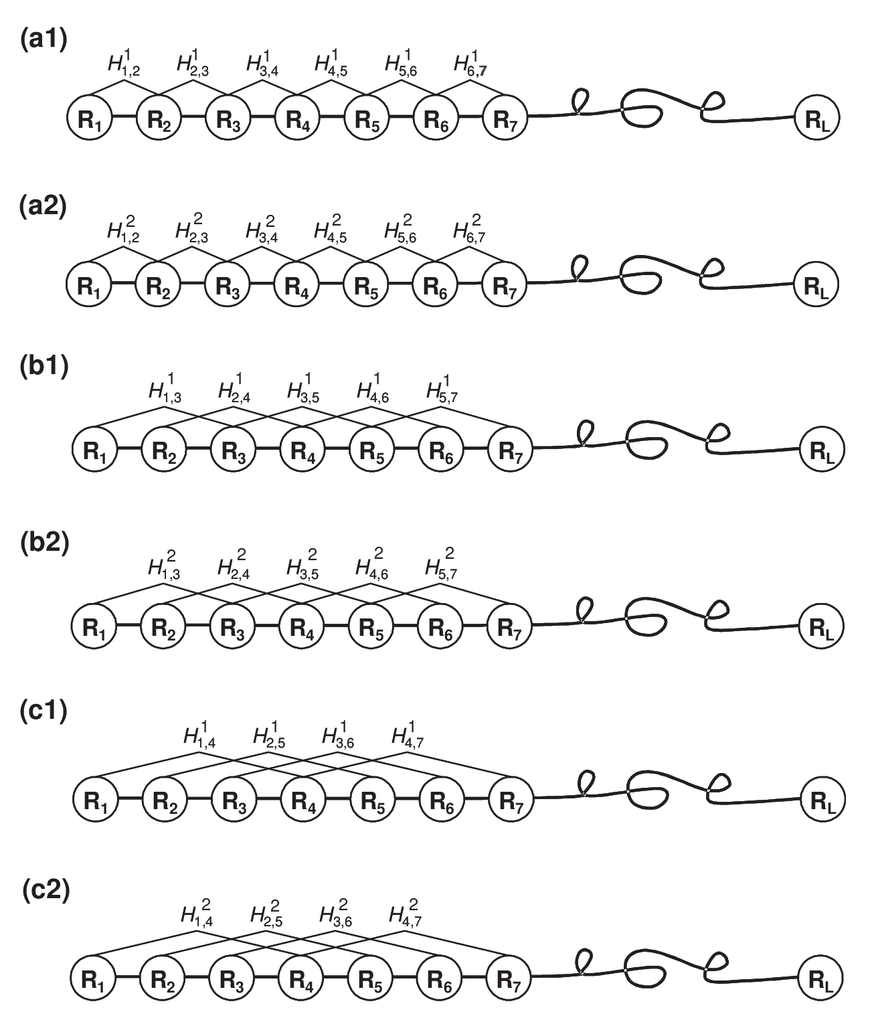

Figure 7: A schematic diagram to show (**a1**/**a2**) the first-rank, (**b1**/**b2**) the second-rank and (**c1**/**c2**) the third-rank sequence-order-coupling mode along a protein sequence through a hydrophobicity/hydrophilicity correlation function, where $H_{i, j}^1$ and $H_{i, j}^2$ are given by Equation (3). Panel (a1/a2) reflects the coupling mode between all the most contiguous residues, panel (b1/b2) that between all the second-most contiguous residues and panel (c1/c2) that between all the third-most contiguous residues. This figure is from Chou (2005).

Then a set of descriptors called *Amphiphilic Pseudo-Amino Acid Composition* (*APseAAC*) are defined as:

$$P_c = \frac{f_c}{\sum_{r=1}^{20} f_r + w \sum_{j=1}^{2 \lambda} \tau_j} \quad (1 < c < 20)$$

$$P_c = \frac{w \tau_u}{\sum_{r=1}^{20} f_r + w \sum_{j=1}^{2 \lambda} \tau_j} \quad (21 < u < 20 + 2 \lambda)$$

where $w$ is the weighting factor. Its default value is set to $w = 0.5$ in protr.

A minimal example for `extracAPAAC()` is:

```r
extractAPAAC(x)
```

```
##                 Pc1.A                 Pc1.R                 Pc1.N
##          3.537412e+01          3.930458e+01          2.161752e+01
##                 Pc1.D                 Pc1.C                 Pc1.E
##          2.849582e+01          3.733935e+01          2.653059e+01
##                 Pc1.Q                 Pc1.G                 Pc1.H
##          2.653059e+01          4.520027e+01          1.670445e+01
##                 Pc1.I                 Pc1.L                 Pc1.K
##          1.965229e+01          4.225242e+01          2.161752e+01
##                 Pc1.M                 Pc1.F                 Pc1.P
##          6.878302e+00          1.768706e+01          2.947844e+01
##                 Pc1.S                 Pc1.T                 Pc1.W
##          4.913073e+01          2.456536e+01          1.277399e+01
##                 Pc1.Y                 Pc1.V  Pc2.Hydrophobicity.1
##          2.358275e+01          2.751321e+01          2.196320e-04
##  Pc2.Hydrophilicity.1  Pc2.Hydrophobicity.2  Pc2.Hydrophilicity.2
##          1.025766e-03         -3.088876e-04         -1.834385e-04
##  Pc2.Hydrophobicity.3  Pc2.Hydrophilicity.3  Pc2.Hydrophobicity.4
##          1.174146e-03          7.400156e-04         -1.105715e-03
##  Pc2.Hydrophilicity.4  Pc2.Hydrophobicity.5  Pc2.Hydrophilicity.5
##         -4.493680e-04          1.766358e-03          1.471212e-03
##  Pc2.Hydrophobicity.6  Pc2.Hydrophilicity.6  Pc2.Hydrophobicity.7
##         -1.441572e-03         -4.913600e-03         -1.678053e-05
##  Pc2.Hydrophilicity.7  Pc2.Hydrophobicity.8  Pc2.Hydrophilicity.8
##          7.312356e-04         -1.885399e-03         -1.928708e-03
##  Pc2.Hydrophobicity.9  Pc2.Hydrophilicity.9 Pc2.Hydrophobicity.10
##         -2.931177e-03         -1.555660e-03          2.916597e-03
## Pc2.Hydrophilicity.10 Pc2.Hydrophobicity.11 Pc2.Hydrophilicity.11
##          3.602591e-03          1.055082e-04          8.697920e-04
## Pc2.Hydrophobicity.12 Pc2.Hydrophilicity.12 Pc2.Hydrophobicity.13
##         -9.276413e-04         -2.001384e-03          1.705044e-03
## Pc2.Hydrophilicity.13 Pc2.Hydrophobicity.14 Pc2.Hydrophilicity.14
##          4.364007e-03          7.883453e-04         -9.441693e-04
## Pc2.Hydrophobicity.15 Pc2.Hydrophilicity.15 Pc2.Hydrophobicity.16
##         -3.133437e-04         -3.599332e-03          3.689079e-05
## Pc2.Hydrophilicity.16 Pc2.Hydrophobicity.17 Pc2.Hydrophilicity.17
##          2.483867e-03          4.832798e-04          2.465788e-03
## Pc2.Hydrophobicity.18 Pc2.Hydrophilicity.18 Pc2.Hydrophobicity.19
##         -3.142728e-04          2.021961e-03          6.421283e-05
## Pc2.Hydrophilicity.19 Pc2.Hydrophobicity.20 Pc2.Hydrophilicity.20
##         -8.896690e-04         -2.986886e-04          9.304039e-04
## Pc2.Hydrophobicity.21 Pc2.Hydrophilicity.21 Pc2.Hydrophobicity.22
##         -6.777458e-04          1.646818e-03          3.193506e-03
## Pc2.Hydrophilicity.22 Pc2.Hydrophobicity.23 Pc2.Hydrophilicity.23
##          3.270656e-03          2.533569e-03          2.478252e-03
## Pc2.Hydrophobicity.24 Pc2.Hydrophilicity.24 Pc2.Hydrophobicity.25
##         -2.489106e-03         -1.031008e-03         -3.992322e-03
## Pc2.Hydrophilicity.25 Pc2.Hydrophobicity.26 Pc2.Hydrophilicity.26
##         -2.596060e-03          8.690771e-04         -1.221378e-03
## Pc2.Hydrophobicity.27 Pc2.Hydrophilicity.27 Pc2.Hydrophobicity.28
##          5.208649e-03          4.617400e-03         -1.088584e-03
## Pc2.Hydrophilicity.28 Pc2.Hydrophobicity.29 Pc2.Hydrophilicity.29
##         -2.512263e-03          1.387641e-03          2.060890e-03
## Pc2.Hydrophobicity.30 Pc2.Hydrophilicity.30
##          3.177340e-04          1.451909e-03
```

This function has the same arguments as `extractPAAC()`.

## 4.10 Profile-Based Descriptors

The profile-based descriptors for protein sequences are available in the protr package. The feature vectors of profile-based methods were based on the PSSM by running PSI-BLAST, and often show good performance. See Ye *et al.* (2011) and Rangwala and Karypis (2005) for details. The functions `extractPSSM()`, `extractPSSMAcc()` and `extractPSSMFeature()` are used to generate these descriptors. Users need to install the NCBI-BLAST+ software package first to make the functions fully functional.

# 5 Descriptors for Proteochemometric Modeling

Proteochemometric (PCM) modeling utilizes statistical modeling techniques to model ligand-target interaction space. The below descriptors implemented in protr are extensively used in Proteochemometric modeling.

- Scales-based descriptors derived by Principal Components Analysis
  - Scales-based descriptors derived by Amino Acid Properties from AAindex (Protein Fingerprint)
  - Scales-based descriptors derived by 20+ classes of 2D and 3D molecular descriptors (Topological, WHIM, VHSE, etc.)
- Scales-based descriptors derived by Factor Analysis
- Scales-based descriptors derived by Multidimensional Scaling
- BLOSUM and PAM matrix-derived descriptors

Note that each of the scales-based descriptor functions are freely to combine with the more than 20 classes of 2D and 3D molecular descriptors to construct highly customized scales-based descriptors. Of course, these functions are designed to be flexible enough that users can provide totally self-defined property matrices to construct scales-based descriptors.

For example, to compute the “topological scales” derived by PCA (using the first 5 principal components), one can use `extractDescScales()`:

```r
x = readFASTA(system.file(
  "protseq/P00750.fasta", package = "protr"))[[1]]

descscales = extractDescScales(
  x, propmat = "AATopo",
  index = c(37:41, 43:47),
  pc = 5, lag = 7, silent = FALSE)
```

```
## Summary of the first 5 principal components:
##                             PC1      PC2       PC3       PC4        PC5
## Standard deviation     2.581537 1.754133 0.4621854 0.1918666 0.08972087
## Proportion of Variance 0.666430 0.307700 0.0213600 0.0036800 0.00080000
## Cumulative Proportion  0.666430 0.974130 0.9954900 0.9991700 0.99998000
```

the argument `propmat` involkes the `AATopo` dataset shipped with the protr package, and the argument `index` selects the 37 to 41 and the 43 to 47 columns (molecular descriptors) in the `AATopo` dataset to use, the parameter `lag` was set for the Auto Cross Covariance (ACC) for generating scales-based descriptors of the same length. At last, we printed the summary of the first 5 principal components (standard deviation, proportion of variance, cumulative proportion of variance).

The result is a length 175 named vector, which is consistent with the descriptors before:

```r
length(descscales)
```

```
## [1] 175
```

```r
head(descscales, 15)
```

```
##     scl1.lag1     scl2.lag1     scl3.lag1     scl4.lag1     scl5.lag1
## -2.645644e-01 -1.717847e-02  1.975438e-02 -7.930659e-05 -3.710597e-05
##     scl1.lag2     scl2.lag2     scl3.lag2     scl4.lag2     scl5.lag2
##  3.548612e-01  1.343712e-01  5.699395e-03 -5.489472e-04 -6.364577e-05
##     scl1.lag3     scl2.lag3     scl3.lag3     scl4.lag3     scl5.lag3
##  2.011431e-02 -9.211136e-02 -1.461755e-03  6.747801e-04  2.386782e-04
```

For another example, to compute the descriptors derived by the BLOSUM62 matrix and use the first 5 scales, one can use:

```r
x = readFASTA(system.file(
  "protseq/P00750.fasta", package = "protr"))[[1]]

blosum = extractBLOSUM(
  x, submat = "AABLOSUM62",
  k = 5, lag = 7, scale = TRUE, silent = FALSE)
```

```
## Relative importance of all the possible 20 scales:
##  [1] 1.204960e+01 7.982007e+00 6.254364e+00 4.533706e+00 4.326286e+00
##  [6] 3.850579e+00 3.752197e+00 3.538207e+00 3.139155e+00 2.546405e+00
## [11] 2.373286e+00 1.666259e+00 1.553126e+00 1.263685e+00 1.024699e+00
## [16] 9.630187e-01 9.225759e-01 7.221636e-01 1.020085e-01 5.868878e-16
```

The result is a length 175 named vector:

```r
length(blosum)
```

```
## [1] 175
```

```r
head(blosum, 15)
```

```
##     scl1.lag1     scl2.lag1     scl3.lag1     scl4.lag1     scl5.lag1
##  0.0042370555 -0.0021502057  0.0005993291  0.0006456375  0.0014849592
##     scl1.lag2     scl2.lag2     scl3.lag2     scl4.lag2     scl5.lag2
## -0.0014919096  0.0032873726  0.0011734162 -0.0021758536 -0.0018127568
##     scl1.lag3     scl2.lag3     scl3.lag3     scl4.lag3     scl5.lag3
## -0.0029413528  0.0001494193  0.0003298806 -0.0017877430 -0.0051044133
```

**Dealing with gaps.** In proteochemometrics, (sequence alignment) gaps can be very useful, since a gap in a certain position contains information. The protr package has built-in support for such gaps. We deal with the gaps by using a dummy descriptor to code for the 21st type of amino acid. The function `extractScalesGap()` and `extractProtFPGap()` can be used to deal with such gaps. See `?extractScalesGap` and `?extractProtFPGap` for details.

# 6 Similarity Calculation by Sequence Alignment

Similarity computation derived by local or global protein sequence alignment between a list of protein sequences is of great need in protein research. However, this type of pairwise similarity computation often computationally intensive, especially when there exists many protein sequences. Luckily, this process is also highly parallelizable, the protr package integrates the function of parallelized similarity computation derived by local or global protein sequence alignment between a list of protein sequences.

The function `twoSeqSim()` calculates the alignment result between two protein sequences. The function `parSeqSim()` calculates the pairwise similarity calculation with a list of protein sequences in parallel:

```r
s1 = readFASTA(system.file("protseq/P00750.fasta", package = "protr"))[[1]]
s2 = readFASTA(system.file("protseq/P08218.fasta", package = "protr"))[[1]]
s3 = readFASTA(system.file("protseq/P10323.fasta", package = "protr"))[[1]]
s4 = readFASTA(system.file("protseq/P20160.fasta", package = "protr"))[[1]]
s5 = readFASTA(system.file("protseq/Q9NZP8.fasta", package = "protr"))[[1]]
plist = list(s1, s2, s3, s4, s5)
psimmat = parSeqSim(plist, cores = 4, type = "local", submat = "BLOSUM62")
print(psimmat)
```

```r
##            [,1]       [,2]       [,3]       [,4]       [,5]
## [1,] 1.00000000 0.11825938 0.10236985 0.04921696 0.03943488
## [2,] 0.11825938 1.00000000 0.18858241 0.12124217 0.06391103
## [3,] 0.10236985 0.18858241 1.00000000 0.05819984 0.06175942
## [4,] 0.04921696 0.12124217 0.05819984 1.00000000 0.05714638
## [5,] 0.03943488 0.06391103 0.06175942 0.05714638 1.00000000
```

We should note that for a small number of proteins, calculating their pairwise similarity scores derived by sequence alignment in parallel may not significantly reduce the overall computation time, since each of the task only requires a relatively small time to finish, thus, computational overheads may exist and affect the performance. In testing, we used about 1,000 protein sequences on 64 CPU cores, and observed significant performance improvement comparing to the sequential computation.

Users should install the packages `foreach` and `doParallel` before using `parSeqSim()`, according to their operation system. The protr package will automatically decide which backend to use.

# 7 Similarity Calculation by GO Semantic Similarity Measures

The protr package also integrates the function of similarity score computation derived by Gene Ontology (GO) semantic similarity measures between a list of GO terms or Entrez Gene IDs.

The function `twoGOSim()` calculates the similarity derived by GO-terms semantic similarity measures between two GO terms / Entrez Gene IDs, and the function `parGOSim()` calculates the pairwise similarity with a list of GO terms / Entrez Gene IDs:

```r
# by GO Terms
go1 = c("GO:0005215", "GO:0005488", "GO:0005515",
        "GO:0005625", "GO:0005802", "GO:0005905")  # AP4B1
go2 = c("GO:0005515", "GO:0005634", "GO:0005681",
        "GO:0008380", "GO:0031202")                # BCAS2
go3 = c("GO:0003735", "GO:0005622", "GO:0005840",
        "GO:0006412")                              # PDE4DIP
glist = list(go1, go2, go3)
gsimmat1 = parGOSim(glist, type = "go", ont = "CC")
print(gsimmat1)
```

```r
##       [,1]  [,2]  [,3]
## [1,] 1.000 0.077 0.055
## [2,] 0.077 1.000 0.220
## [3,] 0.055 0.220 1.000
```

```r
# by Entrez gene id
genelist = list(c("150", "151", "152", "1814", "1815", "1816"))
gsimmat2 = parGOSim(genelist, type = "gene")
print(gsimmat2)
```

```r
##        150   151   152  1814  1815  1816
## 150  0.689 0.335 0.487 0.133 0.169 0.160
## 151  0.335 0.605 0.441 0.171 0.198 0.274
## 152  0.487 0.441 0.591 0.151 0.178 0.198
## 1814 0.133 0.171 0.151 0.512 0.401 0.411
## 1815 0.169 0.198 0.178 0.401 0.619 0.481
## 1816 0.160 0.274 0.198 0.411 0.481 0.819
```

# 8 Miscellaneous Tools

In this section, we will briefly introduce some useful tools provided by the protr package.

## 8.1 Retrieve Protein Sequences from UniProt

This function `getUniProt()` gets protein sequences from uniprot.org by protein ID(s). The input `ID` is a character vector specifying the protein ID(s). The returned sequences are stored in a list:

```r
ids = c("P00750", "P00751", "P00752")
prots = getUniProt(ids)
print(prots)
```

```r
## [[1]]
## [1] "MDAMKRGLCCVLLLCGAVFVSPSQEIHARFRRGARSYQVICRDEKTQMIYQQHQSWLRPVLRSNRVEYCWCN
## SGRAQCHSVPVKSCSEPRCFNGGTCQQALYFSDFVCQCPEGFAGKCCEIDTRATCYEDQGISYRGTWSTAESGAECT
## NWNSSALAQKPYSGRRPDAIRLGLGNHNYCRNPDRDSKPWCYVFKAGKYSSEFCSTPACSEGNSDCYFGNGSAYRGT
## HSLTESGASCLPWNSMILIGKVYTAQNPSAQALGLGKHNYCRNPDGDAKPWCHVLKNRRLTWEYCDVPSCSTCGLRQ
## YSQPQFRIKGGLFADIASHPWQAAIFAKHRRSPGERFLCGGILISSCWILSAAHCFQERFPPHHLTVILGRTYRVVP
## GEEEQKFEVEKYIVHKEFDDDTYDNDIALLQLKSDSSRCAQESSVVRTVCLPPADLQLPDWTECELSGYGKHEALSP
## FYSERLKEAHVRLYPSSRCTSQHLLNRTVTDNMLCAGDTRSGGPQANLHDACQGDSGGPLVCLNDGRMTLVGIISWG
## LGCGQKDVPGVYTKVTNYLDWIRDNMRP"
##
## [[2]]
## [1] "MGSNLSPQLCLMPFILGLLSGGVTTTPWSLARPQGSCSLEGVEIKGGSFRLLQEGQALEYVCPSGFYPYPVQ
## TRTCRSTGSWSTLKTQDQKTVRKAECRAIHCPRPHDFENGEYWPRSPYYNVSDEISFHCYDGYTLRGSANRTCQVNG
## RWSGQTAICDNGAGYCSNPGIPIGTRKVGSQYRLEDSVTYHCSRGLTLRGSQRRTCQEGGSWSGTEPSCQDSFMYDT
## PQEVAEAFLSSLTETIEGVDAEDGHGPGEQQKRKIVLDPSGSMNIYLVLDGSDSIGASNFTGAKKCLVNLIEKVASY
## GVKPRYGLVTYATYPKIWVKVSEADSSNADWVTKQLNEINYEDHKLKSGTNTKKALQAVYSMMSWPDDVPPEGWNRT
## RHVIILMTDGLHNMGGDPITVIDEIRDLLYIGKDRKNPREDYLDVYVFGVGPLVNQVNINALASKKDNEQHVFKVKD
## MENLEDVFYQMIDESQSLSLCGMVWEHRKGTDYHKQPWQAKISVIRPSKGHESCMGAVVSEYFVLTAAHCFTVDDKE
## HSIKVSVGGEKRDLEIEVVLFHPNYNINGKKEAGIPEFYDYDVALIKLKNKLKYGQTIRPICLPCTEGTTRALRLPP
## TTTCQQQKEELLPAQDIKALFVSEEEKKLTRKEVYIKNGDKKGSCERDAQYAPGYDKVKDISEVVTPRFLCTGGVSP
## YADPNTCRGDSGGPLIVHKRSRFIQVGVISWGVVDVCKNQKRQKQVPAHARDFHINLFQVLPWLKEKLQDEDLGFL"
##
## [[3]]
## [1] "APPIQSRIIGGRECEKNSHPWQVAIYHYSSFQCGGVLVNPKWVLTAAHCKNDNYEVWLGRHNLFENENTAQF
## FGVTADFPHPGFNLSLLKXHTKADGKDYSHDLMLLRLQSPAKITDAVKVLELPTQEPELGSTCEASGWGSIEPGPDB
## FEFPDEIQCVQLTLLQNTFCABAHPBKVTESMLCAGYLPGGKDTCMGDSGGPLICNGMWQGITSWGHTPCGSANKPS
## IYTKLIFYLDWINDTITENP"
```

## 8.2 Read FASTA Format files

The function `readFASTA()` provides a convenient way to read protein sequences stored in FASTA format files. See `?readFASTA` for details. The returned sequences are stored in a named list, whose components are named with the protein sequences’ names.

## 8.3 Read PDB Format files

The Protein Data Bank (PDB) file format is a text file format describing the three dimensional structures of protein. The function `readPDB()` provides the function to read protein sequences stored in PDB format files. See `?readPDB` for details.

## 8.4 Sanity Check of the Amino Acid Types

The `protcheck()` function checks if the protein sequence’s amino acid types are in the 20 default types, which returns a `TRUE` if all the amino acids in the sequence belongs to the 20 default types:

```r
x = readFASTA(system.file("protseq/P00750.fasta", package = "protr"))[[1]]
# a real sequence
protcheck(x)
```

```
## [1] TRUE
```

```r
# an artificial sequence
protcheck(paste(x, "Z", sep = ""))
```

```
## [1] FALSE
```

## 8.5 Protein Sequence Partition

The `protseg()` function partitions the protein sequences to create sliding windows. This is usually required when creating feature vectors for machine learning tasks. Users can specify a sequence `x`, and a character `aa`, one of the 20 amino acid types, and a positive integer `k`, which controls the window size (half of the window).

This function returns a named list, each component contains one of the segmentations (a character string), names of the list components are the positions of the specified amino acid in the sequence. See the example below:

```r
protseg(x, aa = "M", k = 5)
```

```
## $`48`
## [1] "DEKTQMIYQQH"
##
## $`242`
## [1] "LPWNSMILIGK"
##
## $`490`
## [1] "TVTDNMLCAGD"
##
## $`525`
## [1] "LNDGRMTLVGI"
```

## 8.6 Auto Cross Covariance (ACC) Computation

Auto Cross Covariance (ACC) is extensively used in the scales-based descriptors computation, this approach calculates the auto covariance and auto cross covariance for generating scale-based descriptors of the same length. Users can write their own scales-based descriptor functions with the help of `acc()` function in the protr package.

## 8.7 Pre-Computed 2D and 3D Descriptor Sets for the 20 Amino Acids

The protr package ships with more than 20 pre-computed 2D and 3D descriptor sets for the 20 amino acids to use with the scales-based descriptors. Please use `data(package = "protr")` to list all the datasets included in the protr package.

## 8.8 BLOSUM and PAM Matrices for the 20 Amino Acids

The BLOSUM and PAM matrices for the 20 amino acids can be used to calculate BLOSUM and PAM matrix-derived descriptors with function `extractBLOSUM()`, the datasets are named in `AABLOSUM45`, `AABLOSUM50`, `AABLOSUM62`, `AABLOSUM80`, `AABLOSUM100`, `AAPAM30`, `AAPAM40`, `AAPAM70`, `AAPAM120`, and `AAPAM250`.

## 8.9 Metadata of the 20 Amino Acids

As the reference, the `AAMetaInfo` dataset includes the meta information of the 20 amino acids used for the 2D and 3D descriptor calculation in the protr package. This dataset include each amino acid’s name, one-letter representation, three-letter representation, SMILE representation, PubChem CID and PubChem link. See `data(AAMetaInfo)` for details.

# 9 ProtrWeb

The web service built on protr, namely ProtrWeb, is located at http://protr.org.

ProtrWeb (Figure 8) does not require any knowledge of programming for the user. It is a user-friendly web application for computing the protein sequence descriptors presented in the protr package.

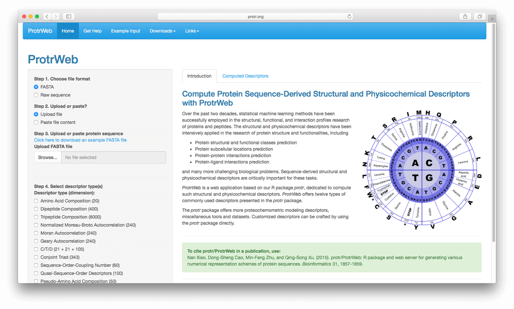

Figure 8: A screenshot of the web application ProtrWeb

Source code repository for this Shiny web application: https://github.com/road2stat/protrweb.

# 10 Summary

The summary of the descriptors in the protr package are listed in Table 3.

Table 3: List of commonly used descriptors in protr

| Descriptor Group | Descriptor Name | Descriptor Dimension | Function Name |
| --- | --- | --- | --- |
| Amino Acid Composition | Amino Acid Composition | 20 | extractAAC() |
|  | Dipeptide Composition | 400 | extractDC() |
|  | Tripeptide Composition | 8000 | extractTC() |
| Autocorrelation | Normalized Moreau-Broto Autocorrelation | 240$^1$ | extractMoreauBroto() |
|  | Moran Autocorrelation | 240$^1$ | extractMoran() |
|  | Geary Autocorrelation | 240$^1$ | extractGeary() |
| CTD | Composition | 21 | extractCTDC(), extractCTDCClass() |
|  | Transition | 21 | extractCTDT(), extractCTDTClass() |
|  | Distribution | 105 | extractCTDD(), extractCTDDClass() |
| Conjoint Triad | Conjoint Triad | 343 | extractCTriad(), extractCTriadClass() |
| Quasi-Sequence-Order | Sequence-Order-Coupling Number | 60$^2$ | extractSOCN() |
|  | Quasi-Sequence-Order Descriptors | 100$^2$ | extractQSO() |
| Pseudo-Amino Acid Composition | Pseudo-Amino Acid Composition | 50$^3$ | extractPAAC() |
|  | Amphiphilic Pseudo-Amino Acid Composition | 80$^4$ | extractAPAAC() |

<sup>1</sup> The number depends on the choice of the number of properties of amino acids and the choice of the maximum values of the `lag`. The default is use 8 types of properties and `lag = 30`.

<sup>2</sup> The number depends on the maximum value of `lag`. By default, `lag = 30`. Two distance matrices are used, so the descriptor dimension is $30 \times 2 = 60$ and $(20 + 30) \times 2 = 100$.

<sup>3</sup> The number depends on the choice of the number of the set of amino acid properties and the choice of the $\lambda$ value. The default is use 3 types of properties proposed by Kuo-Chen Chou and $\lambda = 30$.

<sup>4</sup> The number depends on the choice of the $\lambda$ vlaue. The default is $\lambda = 30$.

The scales-based PCM descriptors in the protr package are listed in Table 4.

Table 4: List of PCM descriptors in protr

| Derived by | Descriptor Class | Function Name |  |
| --- | --- | --- | --- |
| Principal Components Analysis | Scales-based descriptors derived by Principal Components Analysis | extractScales(), extractScalesGap() |  |
|  | Scales-based descriptors derived by amino acid properties from AAindex (a.k.a. Protein Fingerprint) | extractProtFP(), extractProtFPGap() |  |
|  | Scales-based descriptors derived by 2D and 3D molecular descriptors (Topological, WHIM, VHSE, etc.) | extractDescScales() |  |
| Factor Analysis | Scales-based descriptors derived by Factor Analysis | extractFAScales() |  |
| Multidimensional Scaling | Scales-based descriptors derived by Multidimensional Scaling | extractMDSScales() |  |
| Substitution Matrix | BLOSUM and PAM matrix-derived descriptors | extractBLOSUM() |  |

The amino acid descriptor sets used by scales-based descriptors provided by the protr package are listed in Table 5. Note that the non-informative descriptors (like the descriptors have only one value across all the 20 amino acids) in these datasets have already been filtered out.

Table 5: List of the pre-calculated descriptor sets of the 20 amino acids in protr

| Dataset Name | Descriptor Set Name | Dimensionality | Calculated by |
| --- | --- | --- | --- |
| AA2DACOR | 2D Autocorrelations Descriptors | 92 | Dragon |
| AA3DMoRSE | 3D-MoRSE Descriptors | 160 | Dragon |
| AAACF | Atom-Centred Fragments Descriptors | 6 | Dragon |
| AABurden | Burden Eigenvalues Descriptors | 62 | Dragon |
| AAConn | Connectivity Indices Descriptors | 33 | Dragon |
| AAConst | Constitutional Descriptors | 23 | Dragon |
| AAEdgeAdj | Edge Adjacency Indices Descriptors | 97 | Dragon |
| AAEigIdx | Eigenvalue-Based Indices Descriptors | 44 | Dragon |
| AAFGC | Functional Group Counts Descriptors | 5 | Dragon |
| AAGeom | Geometrical Descriptors | 41 | Dragon |
| AAGETAWAY | GETAWAY Descriptors | 194 | Dragon |
| AAInfo | Information Indices Descriptors | 47 | Dragon |
| AAMolProp | Molecular Properties Descriptors | 12 | Dragon |
| AARandic | Randic Molecular Profiles Descriptors | 41 | Dragon |
| AARDF | RDF Descriptors | 82 | Dragon |
| AATopo | Topological Descriptors | 78 | Dragon |
| AATopoChg | Topological Charge Indices Descriptors | 15 | Dragon |
| AAWalk | Walk and Path Counts Descriptors | 40 | Dragon |
| AAWHIM | WHIM Descriptors | 99 | Dragon |
| AACPSA | CPSA Descriptors | 41 | Accelrys Discovery Studio |
| AADescAll | All the 2D Descriptors Calculated by Dragon | 1171 | Dragon |
| AAMOE2D | All the 2D Descriptors Calculated by MOE | 148 | MOE |
| AAMOE3D | All the 3D Descriptors Calculated by MOE | 143 | MOE |

# References

Chou,K.-C. (2001) Prediction of protein cellular attributes using pseudo-amino acid composition. *PROTEINS: Structure, Function, and Genetics*, **43**, 246–255.

Chou,K.-C. (2000) Prediction of protein subcellar locations by incorporating quasi-sequence-order effect. *Biochemical and Biophysical Research Communications*, **278**, 477–483.

Chou,K.-C. (2005) Using amphiphilic pseudo amino acid composition to predict enzyme subfamily classes. *Bioinformatics*, **21**, 10–19.

Chou,K.-C. and Shen,H.-B. (2008) Cell-ploc: A package of web servers for predicting subcellular localization of proteins in various organisms. *Nature Protocols*, **3**, 153–162.

Dubchak,I. *et al.* (1995) Prediction of protein folding class using global description of amino acid sequence. *Proceedings of the National Academy of Sciences*, **92**, 8700–8704.

Dubchak,I. *et al.* (1999) Recognition of a protein fold in the context of the scop classification. *Proteins: Structure, Function and Genetics*, **35**, 401–407.

Grantham,R. (1974) Amino acid difference formula to help explain protein evolution. *Science*, **185**, 862–864.

Kawashima,S. and Kanehisa,M. (2000) AAindex: Amino acid index database. *Nucleic Acids Research*, **28**, 374.

Kawashima,S. *et al.* (1999) AAindex: Amino acid index database. *Nucleic Acids Research*, **27**, 368–369.

Kawashima,S. *et al.* (2008) AAindex: Amino acid index database (progress report). *Nucleic Acids Research*, **36**, D202–D205.

Rangwala,H. and Karypis,G. (2005) Profile-based direct kernels for remote homology detection and fold recognition. *Bioinformatics*, **21**, 4239–4247.

Schneider,G. and Wrede,P. (1994) The rational design of amino acid sequences by artificial neural networks and simulated molecular evolution: Do novo design of an idealized leader cleavage site. *Biophysical Journal*, **66**, 335–344.

Shen,J. *et al.* (2007) Predicting protein-protein interactions based only on sequences information. *Proceedings of the National Academy of Sciences*, **104**, 4337–4341.

Xiao,N. *et al.* (2015) protr/ProtrWeb: R package and web server for generating various numerical representation schemes of protein sequences. *Bioinformatics*, **31**, 1857–1859.

Ye,X. *et al.* (2011) An assessment of substitution scores for protein profile–profile comparison. *Bioinformatics*, **27**, 3356–3363.